# Predicting Heart Disease using Machine Learning

This notebook will introduce some foundation machine learning and data science concepts by exploring the problem of heart disease **classification**.

It is intended to be an end-to-end example of what a data science and machine learning **proof of concept** might look like.

## What we'll end up with

Since we already have a dataset, we'll approach the problem with the following machine learning modelling framework.

[output not shown]

More specifically, we'll look at the following topics.

- **Exploratory data analysis (EDA)** - the process of going through a dataset and finding out more about it.
- **Model training** - create model(s) to learn to predict a target variable based on other variables.
- **Model evaluation** - evaluating a models predictions using problem-specific evaluation metrics.
- **Model comparison** - comparing several different models to find the best one.
- **Model fine-tuning** - once we've found a good model, how can we improve it?
- **Feature importance** - since we're predicting the presence of heart disease, are there some things which are more important for prediction?
- **Cross-validation** - if we do build a good model, can we be sure it will work on unseen data?
- **Reporting what we've found** - if we had to present our work, what would we show someone?

To work through these topics, we'll use pandas, Matplotlib and NumPy for data anaylsis, as well as, Scikit-Learn for machine learning and modelling tasks.

## 1. Problem Definition

In our case, the problem we will be exploring is **binary classification** (a sample can only be one of two things).

This is because we're going to be using a number of differnet **features** (pieces of information) about a person to predict whether they have heart disease or not.

In a statement,

> Given clinical parameters about a patient, can we predict whether or not they have heart disease?

## 2. Data

What you'll want to do here is dive into the data your problem definition is based on. This may involve, sourcing, defining different parameters, talking to experts about it and finding out what you should expect.

The original data came from the [Cleveland database](https://archive.ics.uci.edu/ml/datasets/heart+Disease) from UCI Machine Learning Repository.

Howevever, we've downloaded it in a formatted way from [Kaggle](https://www.kaggle.com/ronitf/heart-disease-uci/).

The original database contains 76 attributes, but here only 14 attributes will be used. **Attributes** (also called **features**) are the variables what we'll use to predict our **target variable**.

Attributes and features are also referred to as **independent variables** and a target variable can be referred to as a **dependent variable**.

> We use the independent variables to predict our dependent variable.

Or in our case, the independent variables are a patients different medical attributes and the dependent variable is whether or not they have heart disease.

## 3. Evaluation

The evaluation metric is something you might define at the start of a project.

Since machine learning is very experimental, you might say something like,

> If we can reach 95% accuracy at predicting whether or not a patient has heart disease during the proof of concept, we'll pursure this project.

The reason this is helpful is it provides a rough goal for a machine learning engineer or data scientist to work towards.

However, due to the nature of experimentation, the evaluation metric may change over time.

## 4. Features

Features are different parts of the data. During this step, you'll want to start finding out what you can about the data.

One of the most common ways to do this, is to create a **data dictionary**.

## Preparing the Tools

```python
# Exploratory Data Analysis and plotting libraries
import pandas as pd
import numpy as np
import ppscore as pps
import matplotlib.pyplot as plt
import seaborn as sns
sns.set()
# we want our plots to appear inside the notebook
%matplotlib inline

# Models from Sklearn
from sklearn.linear_model import LogisticRegression
from sklearn.neighbors import KNeighborsClassifier
from sklearn.tree import DecisionTreeClassifier
from sklearn.ensemble import RandomForestClassifier
from sklearn.ensemble import GradientBoostingClassifier


# Model Evaluations
from sklearn.model_selection import train_test_split, cross_val_score
from sklearn.model_selection import RandomizedSearchCV, GridSearchCV # hyperparameter tuning
from sklearn.metrics import confusion_matrix, classification_report
from sklearn.metrics import precision_score, recall_score, f1_score
from sklearn.metrics import plot_roc_curve
from sklearn.model_selection import RepeatedStratifiedKFold
```

# Load Our Data

```python
df = pd.read_csv('../Datasets/heart-disease.csv')
df.head()
```

|  | age | sex | cp | trestbps | chol | fbs | restecg | thalach | exang | oldpeak | slope | ca | thal | target |
| --- | --- | --- | --- | --- | --- | --- | --- | --- | --- | --- | --- | --- | --- | --- |
| 0 | 63 | 1 | 3 | 145 | 233 | 1 | 0 | 150 | 0 | 2.3 | 0 | 0 | 1 | 1 |
| 1 | 37 | 1 | 2 | 130 | 250 | 0 | 1 | 187 | 0 | 3.5 | 0 | 0 | 2 | 1 |
| 2 | 41 | 0 | 1 | 130 | 204 | 0 | 0 | 172 | 0 | 1.4 | 2 | 0 | 2 | 1 |
| 3 | 56 | 1 | 1 | 120 | 236 | 0 | 1 | 178 | 0 | 0.8 | 2 | 0 | 2 | 1 |
| 4 | 57 | 0 | 0 | 120 | 354 | 0 | 1 | 163 | 1 | 0.6 | 2 | 0 | 2 | 1 |

# Data Exploration (exploratory data analysis or EDA)

The goal here is to find out more about the data and understand the data we're working with.

1. What question(s) am I trying to solve?
2. What kind of data do we have and how do we treat different types?
3. What's missing from the data and how do I deal with it?
4. Where are the outliers and why should I care about them?
5. How can you add, change or remove features to get more out of your data?

```python
df.head(2)
```

|  | age | sex | cp | trestbps | chol | fbs | restecg | thalach | exang | oldpeak | slope | ca | thal | target |
| --- | --- | --- | --- | --- | --- | --- | --- | --- | --- | --- | --- | --- | --- | --- |
| 0 | 63 | 1 | 3 | 145 | 233 | 1 | 0 | 150 | 0 | 2.3 | 0 | 0 | 1 | 1 |
| 1 | 37 | 1 | 2 | 130 | 250 | 0 | 1 | 187 | 0 | 3.5 | 0 | 0 | 2 | 1 |

```python
# how many of each class their are?
# Is our data unbalanced?
df['target'].value_counts()
```

```
1    165
0    138
Name: target, dtype: int64
```

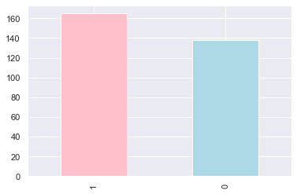

```python
df['target'].value_counts().plot(kind='bar', color=['pink', 'lightblue']);
```

```python
df.info()
```

```
<class 'pandas.core.frame.DataFrame'>
RangeIndex: 303 entries, 0 to 302
Data columns (total 14 columns):
 #   Column    Non-Null Count  Dtype
---  ------    --------------  -----
 0   age       303 non-null    int64
 1   sex       303 non-null    int64
 2   cp        303 non-null    int64
 3   trestbps  303 non-null    int64
 4   chol      303 non-null    int64
 5   fbs       303 non-null    int64
 6   restecg   303 non-null    int64
 7   thalach   303 non-null    int64
 8   exang     303 non-null    int64
 9   oldpeak   303 non-null    float64
 10  slope     303 non-null    int64
 11  ca        303 non-null    int64
 12  thal      303 non-null    int64
 13  target    303 non-null    int64
dtypes: float64(1), int64(13)
memory usage: 33.3 KB
```

```python
# Are there any missing values?
df.isna().sum()
```

```
age         0
sex         0
cp          0
trestbps    0
chol        0
fbs         0
restecg     0
thalach     0
exang       0
oldpeak     0
slope       0
ca          0
thal        0
target      0
dtype: int64
```

```python
df.describe()
```

|  | age | sex | cp | trestbps | chol | fbs | restecg | thalach | exang | oldpeak | slope | ca | thal | target |
| --- | --- | --- | --- | --- | --- | --- | --- | --- | --- | --- | --- | --- | --- | --- |
| count | 303.000000 | 303.000000 | 303.000000 | 303.000000 | 303.000000 | 303.000000 | 303.000000 | 303.000000 | 303.000000 | 303.000000 | 303.000000 | 303.000000 | 303.000000 | 303.000000 |
| mean | 54.366337 | 0.683168 | 0.966997 | 131.623762 | 246.264026 | 0.148515 | 0.528053 | 149.646865 | 0.326733 | 1.039604 | 1.399340 | 0.729373 | 2.313531 | 0.544554 |
| std | 9.082101 | 0.466011 | 1.032052 | 17.538143 | 51.830751 | 0.356198 | 0.525860 | 22.905161 | 0.469794 | 1.161075 | 0.616226 | 1.022606 | 0.612277 | 0.498835 |
| min | 29.000000 | 0.000000 | 0.000000 | 94.000000 | 126.000000 | 0.000000 | 0.000000 | 71.000000 | 0.000000 | 0.000000 | 0.000000 | 0.000000 | 0.000000 | 0.000000 |
| 25% | 47.500000 | 0.000000 | 0.000000 | 120.000000 | 211.000000 | 0.000000 | 0.000000 | 133.500000 | 0.000000 | 0.000000 | 1.000000 | 0.000000 | 2.000000 | 0.000000 |
| 50% | 55.000000 | 1.000000 | 1.000000 | 130.000000 | 240.000000 | 0.000000 | 1.000000 | 153.000000 | 0.000000 | 0.800000 | 1.000000 | 0.000000 | 2.000000 | 1.000000 |
| 75% | 61.000000 | 1.000000 | 2.000000 | 140.000000 | 274.500000 | 0.000000 | 1.000000 | 166.000000 | 1.000000 | 1.600000 | 2.000000 | 1.000000 | 3.000000 | 1.000000 |
| max | 77.000000 | 1.000000 | 3.000000 | 200.000000 | 564.000000 | 1.000000 | 2.000000 | 202.000000 | 1.000000 | 6.200000 | 2.000000 | 4.000000 | 3.000000 | 1.000000 |

# Finding Patterns In Data

## Heart Disease Frequency according to Sex

```python
df.sex.value_counts()
```

```
1    207
0     96
Name: sex, dtype: int64
```

```python
# Compare target column with sex column
pd.crosstab(df['target'], df['sex'])
```

| sex target | 0 | 1 |
| --- | --- | --- |
| 0 | 24 | 114 |
| 1 | 72 | 93 |

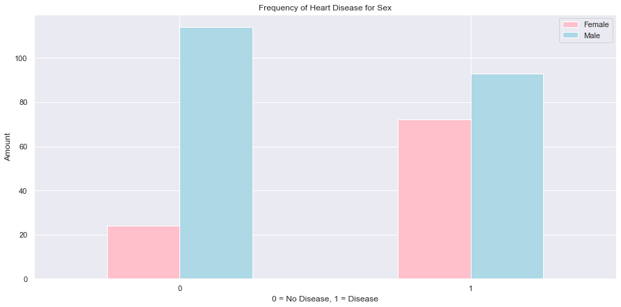

```python
# create plot for crosstab
pd.crosstab(df['target'], df['sex']).plot(kind='bar', figsize=(15, 7), color=['pink', 'lightblue'])
plt.title('Frequency of Heart Disease for Sex')
plt.xlabel('0 = No Disease, 1 = Disease')
plt.ylabel('Amount')
plt.legend(['Female', 'Male']);
plt.xticks(rotation=0);
```

## Heart Disease Frequency Given Age

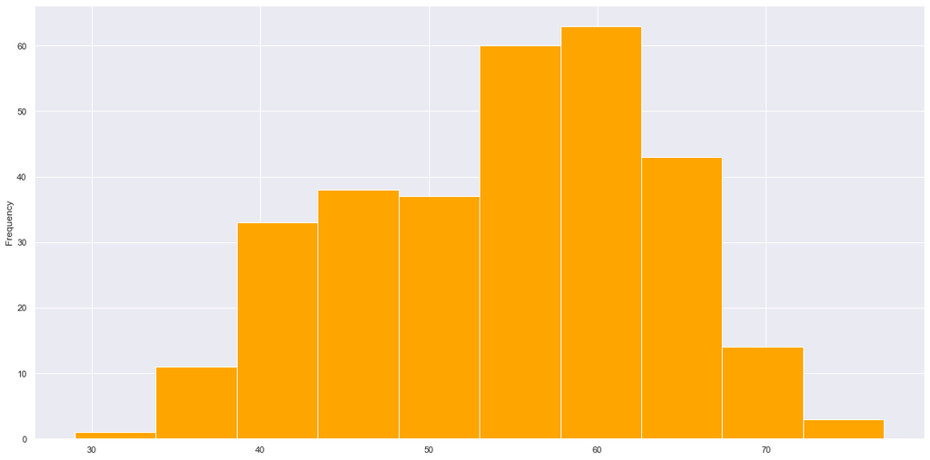

```python
# distribution of Age
df['age'].plot(kind='hist', figsize=(20,10), color=['orange'])
```

```python
df.age.mean()
```

```
54.366336633663366
```

- Average age in our dataset is 54.

```python
df[(df['target']==1) & (df['age']>1)].mean()
#pd.crosstab(df['target'], df['age']).plot(kind='hist', figsize=(50, 30))
```

```
age          52.496970
sex           0.563636
cp            1.375758
trestbps    129.303030
chol        242.230303
fbs           0.139394
restecg       0.593939
thalach     158.466667
exang         0.139394
oldpeak       0.583030
slope         1.593939
ca            0.363636
thal          2.121212
target        1.000000
dtype: float64
```

- The average age for people in our dataset that have heart disease is 52 years of age and the majority of them are male.

## Comparing Age vs Thalach and Heart Disease

- Thalach: Maximum heart rate achieved

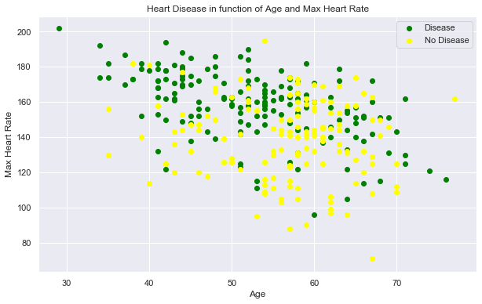

```python
# Create another figure
plt.figure(figsize=(10,6))
# scatter with positive examples
plt.scatter(df.age[df.target==1],df.thalach[df.target==1],
           c='green')
# scatter with negative examples
plt.scatter(df.age[df.target==0], df.thalach[df.target==0], c='yellow');
# add some helpful info
plt.title('Heart Disease in function of Age and Max Heart Rate')
plt.xlabel('Age')
plt.ylabel('Max Heart Rate')
plt.legend(['Disease', 'No Disease']);
```

### Heart Disease Frequency per Chest Pain Type

1. cp - chest pain type
   - 0: Typical angina: chest pain related decrease blood supply to the heart
   - 1: Atypical angina: chest pain not related to heart
   - 2: Non-anginal pain: typically esophageal spasms (non heart related)
   - 3: Asymptomatic: chest pain not showing signs of disease

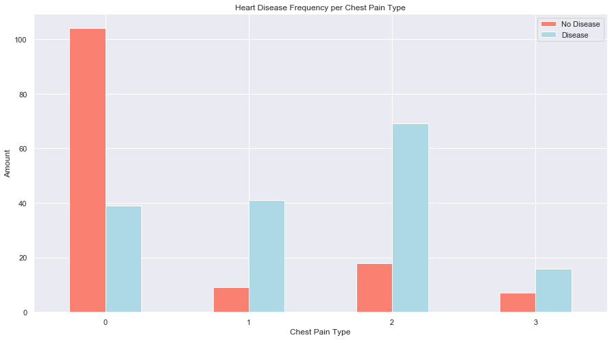

```python
pd.crosstab(df['cp'], df['target']).plot(kind='bar', figsize=(15, 8), color=['salmon', 'lightblue']);

plt.title('Heart Disease Frequency per Chest Pain Type')
plt.xlabel('Chest Pain Type')
plt.ylabel('Amount')
plt.legend(['No Disease', 'Disease'])
plt.xticks(rotation=0);
```

### Apply Correlation Matrix

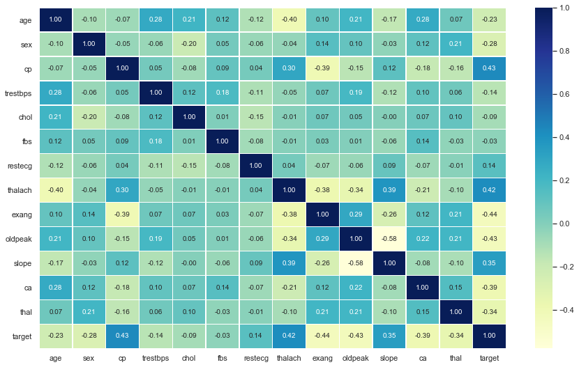

```python
corr_matrix = df.corr()
fig, ax = plt.subplots(figsize=(15,9))
ax = sns.heatmap(corr_matrix, annot=True, linewidths=0.5, fmt='.2f',cmap='YlGnBu');
```

- Negative Correlation => a relationship where one variable increases as the other decreases
- Positive Correlation => relationship where when one variable increases the other variable increases and if one varable decreases the other variable decreases

## 5. Modelling

We'll train it (find the pattens) on the training set.

And we'll test it (use the patterns) on the test set.

1. Logistic Regression
2. K-Nearest Neighbors Classifier
3. Random Forest Classifier
4. GradientBoostingClassifier

```python
# Put models in dictionary

models = { "Logistic Regresion": LogisticRegression(),
         "KNN": KNeighborsClassifier(),
          "Decision Tree": DecisionTreeClassifier(),
         "Random Forest": RandomForestClassifier(),
         "Gradient Boosting Classifier": GradientBoostingClassifier()}

# Create a function to fit and score models

def fit_and_score(models, X_train, X_test, y_train, y_test):
    """ Fits and evaluates given machine learning models.
    models: a dict of different Scikit-Learrn machine learning models
    X_train: training data (no labels)
    X_test: testing data (no labels)
    y_train: training labels
    y_test: test labels
    """

    # Set random seed
    np.random.seed(42)
    # Make a dictionary to keep model scores
    model_scores = {}
    # Loop through models
    for name, model in models.items():
        # Fit the model to the data
        model.fit(X_train, y_train)
        # Evaluate the model and append its score to model_scores
        model_scores[name] = model.score(X_test, y_test)

    return model_scores
```

```python
model_scores = fit_and_score(models=models,
                            X_train=X_train,
                            X_test=X_test,
                            y_train=y_train,
                            y_test=y_test)
model_scores
```

```
{'Logistic Regresion': 0.8852459016393442,
 'KNN': 0.6885245901639344,
 'Decision Tree': 0.7540983606557377,
 'Random Forest': 0.8360655737704918,
 'Gradient Boosting Classifier': 0.7704918032786885}
```

## Model Comparison

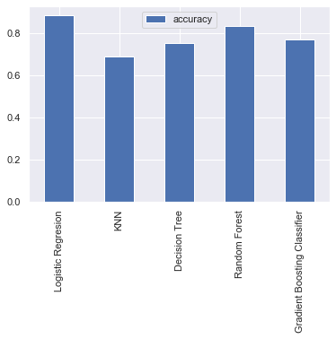

```python
model_compare = pd.DataFrame(model_scores, index=["accuracy"])
model_compare.T.plot.bar();
```

Now we've got a baseline model... and we know a model's first predictions aren't always what we should based our next steps off. What should do?

Let's look at the following:

- Hyperparameter tuning
- Feature Importance
- Confusion Matrix
- Cross-Validation
- Precision
- Recall
- F1 Score
- Classification Report
- ROC Curve
- Area under the curve (AUC)\

## Hyperparameter Tuning

```python
# Let's tune KNN

train_scores = []
test_scores = []

# Create a list of different values for n_neighbors
neighbors = range(1, 21) # range 1 - 20

# setup KNN instance
knn = KNeighborsClassifier()

for i in neighbors:
    knn.set_params(n_neighbors=i)

    # Fit the algorithm
    knn.fit(X_train, y_train)

    # Update training scores list
    train_scores.append(knn.score(X_train, y_train))

    # Update testing scores list
    test_scores.append(knn.score(X_test, y_test))
```

```
Maximum score of KNN on test data: 75.41%
```

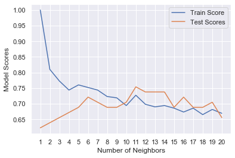

```python
plt.plot(neighbors,train_scores,label='Train Score')
plt.plot(neighbors, test_scores, label='Test Scores')
plt.xticks(np.arange(1, 21, 1)) # a list of range 1 - 20
plt.xlabel('Number of Neighbors')
plt.ylabel('Model Scores')
plt.legend()

print(f"Maximum score of KNN on test data: {max(test_scores)*100:.2f}%")
```

## Hyperparameter Tuning Randomized Search CV

We're going to tune:

- LogisticRegression()
- DecisionTreeClassifier()
- RandomForestClassifier()
- GradientBoostingClassifier()

*** using RandomizedGridSearchCV

Cross Validation => creates different versions of training data given (f-fold) and evaluated on 5 different versions of the test data.

```python
# Create a hyperparameter grid for logistic regression
log_reg_grid = {"C": np.logspace(-4, 4, 20),
               "solver": ['liblinear']}

# Hyperparameter grid for decision tree classifier
dtc_grid = {"criterion": ['gini', 'entropy'],
            "max_depth": [4, 6, 8, 12],
            "min_samples_split": np.arange(2, 20,2),
            "min_samples_leaf": np.arange(1, 20, 2),
            "splitter": ["best", "random"],
           }

# Create hyperparameter grid for random forest classifier
rfc_grid = {"n_estimators": np.arange(10, 1000, 50),
           "max_depth": [None, 3, 5, 10],
           "min_samples_split": np.arange(2, 20, 2),
           "min_samples_leaf": np.arange(1, 20, 2)}

# Create hyperparameter grid for gradient boosting classifier
gbc_grid = {'n_estimators': np.arange(20,81,10),
           'max_depth':range(5,16,2),
           'min_samples_split':range(200,1001,200),
           'min_samples_leaf':range(30,71,10)}
```

Looks like our LogisticRegression Classifier is the same accuracy after hyperparameter tuning. This model must be very good our of the box with this dataset.

Let's do the same for the DecisionTreeClassifier()

Awesome! Our Gradient Boosting Classifier's accuracy improved by 8%.

```python
model_scores
```

```
{'Logistic Regresion': 0.8852459016393442,
 'KNN': 0.6885245901639344,
 'Decision Tree': 0.7540983606557377,
 'Random Forest': 0.8360655737704918,
 'Gradient Boosting Classifier': 0.7704918032786885}
```

### Compare Randomized Search Hyperparmeterized Models

```python
new_model_scores
```

```
{'Logistic Regresion': 0.8852459016393442,
 'Decision Tree': 0.7377049180327869,
 'Random Forest': 0.8688524590163934,
 'Gradient Boosting Classifier': 0.8524590163934426}
```

```python
model_scores
```

```
{'Logistic Regresion': 0.8852459016393442,
 'KNN': 0.6885245901639344,
 'Decision Tree': 0.7540983606557377,
 'Random Forest': 0.8360655737704918,
 'Gradient Boosting Classifier': 0.7704918032786885}
```

# Hyperparameter Tuning with GridSearchCV

Since our LogisticRegression model provides the best scores so far, we'll try and improve them again using GridSearchCV..

```python
# Different LogisticRegression hyperparameters
log_reg_grid = {"C": np.logspace(-4, 4, 30),
                "solver": ["liblinear"]}

# Setup grid hyperparameter search for LogisticRegression
gs_log_reg = GridSearchCV(LogisticRegression(),
                          param_grid=log_reg_grid,
                          cv=5,
                          verbose=True)

# Fit grid hyperparameter search model
gs_log_reg.fit(X_train, y_train);
```

```
Fitting 5 folds for each of 30 candidates, totalling 150 fits
```

```
[Parallel(n_jobs=1)]: Using backend SequentialBackend with 1 concurrent workers.
[Parallel(n_jobs=1)]: Done 150 out of 150 | elapsed:    1.1s finished
```

```python
# Evaluate the model
gs_log_reg.score(X_test, y_test)
```

```
0.8852459016393442
```

**Note:** If there are a large amount of hyperparameters combinations in your grid, `GridSearchCV` may take a long time to try them all out. This is why it's a good idea to start with `RandomizedSearchCV`, try a certain amount of combinations and then use `GridSearchCV` to refine them.

## Evaluating a classification model, beyond accuracy

Now we've got a tuned model, let's get some of the metrics we discussed before.

We want:

- ROC curve and AUC score - [`plot_roc_curve()`](https://scikit-learn.org/stable/modules/generated/sklearn.metrics.plot_roc_curve.html#sklearn.metrics.plot_roc_curve)
- Confusion matrix - [`confusion_matrix()`](https://scikit-learn.org/stable/modules/generated/sklearn.metrics.confusion_matrix.html)
- Classification report - [`classification_report()`](https://scikit-learn.org/stable/modules/generated/sklearn.metrics.classification_report.html)
- Precision - [`precision_score()`](https://scikit-learn.org/stable/modules/generated/sklearn.metrics.precision_score.html)
- Recall - [`recall_score()`](https://scikit-learn.org/stable/modules/generated/sklearn.metrics.recall_score.html)
- F1-score - [`f1_score()`](https://scikit-learn.org/stable/modules/generated/sklearn.metrics.f1_score.html)

Luckily, Scikit-Learn has these all built-in.

To access them, we'll have to use our model to make predictions on the test set. You can make predictions by calling `predict()` on a trained model and passing it the data you'd like to predict on.

Let's start with the ROC curve and AUC scores.